# Sinoph disinfo

JC De Orellana Sanchez

2024-05-28

## Content

This code preprocess and cleans the data. It 1. Opens json files containing dictionaries with video metadata downloaded from YouTube. 2. Converts dates in UNIX format into regular `Date` format and counts from `character` into numeric format. 3. Creates the program column and fills it with the program titles extracted from the video_title data downloaded from the API. If video_title does not contain the program name, it insters NA. 4. Standardizes the programs’ names and cleans the titles by extracting the program name 5. Creates a dataframe to analyze and visualize the data using ggplot 6. Replaces NAs in the program columns with the manually found show names 7. Creates a .csv file with the dataframe.

The code after takes the df created above and creates 3 scatter-plots. It 8. Uses geom_jitter to counter point overlap. 9. Create 3 separate plots to visualize the number of views, likes, and comments that the anti-Sinopharm malinformation videos received 10. Selects video of March 5 2021 as a case study 11. Loads the comments and related metadata into a dataframe 12. Saves dataframe for hand-coding using a 0-3 scale (0 = Neurtral, 1 = In-line politically, 2 = In-line w/Sinopharm disinfo, 3 = Against video) 13 Loads hand-coded file

### TO DO:

Keep parsing the vide_title metadata to extract the dates in which the programs were aired and keep the title column only with the video titles

```r
# Load data
# file_path <- rio::import("data/willax_pbo_youtube_vids/sinoph_pbo_willax_disinfo.json")

# Create df. Data preprocess and cleaning
# video_data <- file_path |>
#   mutate(video_publish_date = as_date(as_datetime(video_publish_date, origin = "1970-01-01"))) |>
#   # Replace 'FALSE' or any non-numeric values with 0
#   mutate(video_dislike_count = ifelse(!is.na(as.numeric(video_dislike_count)), as.numeric(video_dislike_count), 0)) |>
#   mutate(video_view_count = as.numeric(video_view_count)) |>
#   mutate(video_comment_count = as.numeric(video_comment_count))  |>
#   mutate(video_like_count = as.numeric(video_like_count)) |>
#   mutate(program = if_else(
#     str_starts(video_title, "Ernesto"),
#     NA_character_,  # If title starts with Ernesto, set to NA or keep the original
#     str_extract(video_title, "^[^:\\-]+(?=\\:|\\s?-\\s?)")  # Otherwise, extract the program name
#   )) |>
#   mutate(program = str_replace_all(program,
#                                    c("MilagrosLeivaEntrevista" = "Milagros Leiva Entrevista",
#                                      "Milagros LeivaEntrevista" = "Milagros Leiva Entrevista"))) |>
#   mutate(video_title = case_when(
#     str_detect(video_title, "^(Milagros)") ~ str_replace(video_title, ".*? - ", ""),
#     TRUE ~ video_title)) |>
#   mutate(video_title = case_when(
#     str_detect(video_title, "^(Combutters: )") ~ str_replace(video_title, "Combutters: ", ""),
#     TRUE ~ video_title
#   )) |>
#   mutate(video_title = case_when(
#     str_detect(video_title, "^(Beto a Saber|Combutters)") ~ str_replace(video_title, ".*? - ", ""), TRUE ~ video_title
#   )) |>
#   mutate(program_date = str_extract(video_title, "(ENE|FEB|MAR|ABR|MAY|JUN|JUL|AGO|SEP|OCT|NOV|DIC)\\s?\\d{2}"),
#          str_remove_all(video_title, "(ENE|FEB|MAR|ABR|MAY|JUN|JUL|AGO|SEP|OCT|NOV|DIC)\\s?\\d{2}\\s?-\\s?")
#          ) |>
#   mutate(video_description = str_remove_all(video_description, "(facebook.com/willaxtv|twitter.com/willaxtv)")
#          ) |>
#   mutate(video_description = str_remove_all(video_description,
#                                             "Transmite en HD a través del canal 1.1 de señal abierta digital \\(TDT\\), MovistarTV C16 y 716HD, ClaroTV C12 y 512HD, DirecTV 1191HD, Best Cable C8 y más de 100 cableoperadores a nivel nacional\\.\\s*Consulta la programación de Willax Televisión aquí y conoce la hora de emisión de todos los programas de entretenimiento, novelas, programas y debates políticos: http://willax.tv/Programacion")
#          ) |>
#   select(video_id,
#          channel_title,
#          channel_id,
#          video_publish_date,
#          program,
#          program_date,
#          video_title,
#          video_description,
#          video_view_count,
#          video_comment_count,
#          video_like_count,
#          video_dislike_count,
#          video_tags)|>
#   arrange(video_publish_date)
#
# video_data[[5]][1] = "Milagros Leiva Entrevista"
# video_data[[5]][[3]] = "Beto a Saber"
# video_data[[5]][70] = "PBO"
# video_data[[5]][101] = "PBO"

# Commands to debug/check the resulting df
# str(video_data)
# head(video_data)
# summary(video_data)

# Create a .csv file with the dataframe
#write.csv(video_data, "data/willax_pbo_youtube_vids/df_sinoph_pbo_willax_disinfo_long.csv", row.names = FALSE)
```

### Table organizing the 2020 - 2021 videos by date

| Channel | Published | Program | Aired | Title | Views | Comments | Likes |
| --- | --- | --- | --- | --- | --- | --- | --- |
| Willax | 2020-10-07 | Milagros Leiva Entrevista | OCT 06 | Ernesto Bustamante anuncia participación en lista congresal de Fuerza Popular | 636 | 3 | 19 |
| PBO | 2020-10-24 | PBO MEDIODÍA | OCT 24 | Exjefe del INS Ernesto Bustamante sobre la segunda ola COVID 19 y FUERZA POPULAR y KEIKO FUJIMORI | 7266 | 22 | 310 |
| Willax | 2020-10-29 | Combutters | OCT 28 | Segunda ola llegó a europa - 3/4 | 4750 | 1 | 111 |
| Willax | 2020-11-07 | Beto a Saber | NOV 05 | Ernesto Bustamante: ""La propaganda de Vizcarra es de mal gusto"" | 630 | 1 | 10 |
| Willax | 2020-11-17 | Combutters | NOV 16 | Vacuna estadounidense pasa a la delantera - 4/4 | 2090 | 7 | 41 |
| Willax | 2020-12-03 | Combutters | DIC 02 | VACUNA: HAY LUZ AL FINAL DEL TÚNEL - 3/4 | 2340 | 11 | 60 |
| Willax | 2020-12-15 | Milagros Leiva Entrevista | DIC 14 | PALABRAS, PALABRAS, PALABRAS: EL CUENTO DE LAS VACUNAS - 1/4\|Willax | 10207 | 94 | 323 |
| Willax | 2020-12-15 | Milagros Leiva Entrevista | DIC 14 | ""LA VACUNA NO ESTARÁ A LA VUELTA DE LA ESQUINA"" - 2/4 | 10278 | 45 | 255 |
| Willax | 2020-12-15 | Beto a Saber | DIC 14 | MIRA QUIÉN HABLA - 2/3 | 145626 | 901 | 2062 |
| Willax | 2020-12-15 | Combutters | DIC 14 | LA `MECIDA´ DE LA VACUNA - 1/4 | 19823 | 106 | 606 |
| Willax | 2020-12-16 | Milagros Leiva Entrevista | DIC 15 | MÁS CERCA DE LA SEGUNDA OLA QUE DE LAS VACUNAS - 1/4 | 8813 | 67 | 226 |
| Willax | 2020-12-16 | Milagros Leiva Entrevista | DIC 15 | ""EL MANEJO DE LA PANDEMIA HA SIDO CATASTRÓFICO"" - 2/4 | 8165 | 46 | 214 |
| Willax | 2020-12-16 | Combutters | DIC 15 | VACUNA: LA CANCILLER NO ASUME NADA - 2/4 | 15230 | 74 | 439 |
| Willax | 2020-12-17 | Milagros Leiva Entrevista | DIC 16 | A FALTA DE VACUNAS, VUELVEN LAS RESTRICCIONES - 1/4 \|Willax | 10585 | 73 | 259 |
| Willax | 2020-12-18 | Milagros Leiva Entrevista | DIC 17 | VIZCARRA Y LA VACUNA QUE NO LLEGARÁ - 1/4 | 13422 | 141 | 344 |
| Willax | 2020-12-19 | Milagros Leiva Entrevista | DIC 18 | LAS FALSAS PROMESAS DE PILAR MAZZETTI - 1/4 | 16846 | 124 | 395 |
| Willax | 2020-12-19 | Milagros Leiva Entrevista | DIC 18 | CHILE Y COLOMBIA YA TIENEN LA VACUNA - 2/4 | 42140 | 429 | 873 |
| Willax | 2020-12-22 | Milagros Leiva Entrevista | DIC 21 | ALARMA MUNDIAL POR NUEVA VARIANTE DEL CORONAVIRUS - 1/4 | 9806 | 56 | 189 |
| Willax | 2020-12-22 | Combutters | DIC 21 | QUÉ TAL ‘CARE PALO’ - 2/4 | 27340 | 144 | 622 |
| Willax | 2020-12-24 | Milagros Leiva Entrevista | DIC 23 | ¿EL APRA NUNCA MUERE? - 1/4 | 16315 | 131 | 290 |
| Willax | 2020-12-29 | Milagros Leiva Entrevista | DIC 28 | ¿QUIÉNES SON LOS RESPONSABLES DE QUE NO TENGAMOS VACUNA? - 4/4\|Willax | 3586 | 9 | 90 |
| Willax | 2020-12-29 | Beto a Saber | DIC 28 | ¿ESTAMOS YA ANTE LA SEGUNDA OLA? - 2/3 | 40812 | 194 | 918 |
| Willax | 2020-12-30 | Combutters | DIC 29 | VIZCARRA SOBRE VACUNA: ""SE PAGÓ"" - 1/4 | 23262 | 172 | 567 |

### Table with first videos of 2021 about the COVID vaccine

Videos 2021 (first 20) )

| Channel | Published | Program | Aired | Title | Views | Comments | Likes |
| --- | --- | --- | --- | --- | --- | --- | --- |
| Willax | 2021-01-05 | Milagros Leiva Entrevista | ENE 04 | PRESIDENTE SAGASTI,¿CUÁNDO LLEGARÁN LAS VACUNAS? - 1/4 | 9895 | 80 | 193 |
| Willax | 2021-01-06 | Milagros Leiva Entrevista | ENE 05 | MAZZETTI: ""ENCONTRAR AL CULPABLE ES EL DEPORTE NACIONAL” - 1/4\|Willax | 7826 | 77 | 160 |
| Willax | 2021-01-07 | Milagros Leiva Entrevista | ENE 06 | LA PRIMERA BUENA NUEVA DEL 2021 - 1/4 | 8456 | 55 | 134 |
| Willax | 2021-01-07 | Beto a Saber | ENE 06 | LA GRAN HAZAÑA DE SAGASTI - 1/3 | 99112 | 804 | 1727 |
| Willax | 2021-01-09 | Beto a Saber | ENE 08 | LLEGÓ EL VIRUS INGLÉS - 1/3 | 86458 | 507 | 1621 |
| Willax | 2021-01-12 | Combutters | ENE 11 | LA VACUNA QUE ESCOGEN LOS POLÍTICOS - 1/4 | 15450 | 58 | 368 |
| Willax | 2021-01-13 | Beto a Saber | ENE 12 | VACUNA COVID-19 NO PODRÁ SER COMERCIALIZADA POR PRIVADOS - 2/3 | 31325 | 118 | 674 |
| Willax | 2021-01-13 | Combutters | ENE 12 | GOBIERNO ADMITE SEGUNDA OLA - 1/4 | 17910 | 60 | 420 |
| Willax | 2021-01-16 | Combutters | ENE 15 | VACUNACIÓN: PELIGROSA PROMESA - 1/4 | 19043 | 56 | 408 |
| Willax | 2021-01-19 | Milagros Leiva Entrevista | ENE 18 | SOLO QUEDAN 125 CAMAS UCI EN TODO EL PAÍS - 2/4 | 5194 | 26 | 109 |
| Willax | 2021-01-21 | Beto a Saber | ENE 20 | SÁLVESE QUIEN SEPA - 2/3 | 49275 | 165 | 811 |
| Willax | 2021-01-21 | Combutters | ENE 20 | VACUNA: ESTAMOS ENTRE LOS ÚLTIMOS DE LA FILA - 3/4 | 14973 | 51 | 374 |
| Willax | 2021-01-23 | Milagros Leiva Entrevista | ENE 22 | LA EFICACIA DE LAS VACUNAS QUE LLEGARÁN AL PERÚ - 3/4 | 4379 | 24 | 84 |
| Willax | 2021-01-26 | Milagros Leiva Entrevista | ENE 2 | REINFECCIONES POR COVID-19: SE VEN CASOS DESDE DICIEMBRE - 2/4 | 2157 | 10 | 49 |
| Willax | 2021-01-26 | Milagros Leiva Entrevista | ENE 25 | 19 ""ESTÁ CASI INCONTROLABLE” -1/4 | 5285 | 51 | 97 |
| Willax | 2021-01-27 | Milagros Leiva Entrevista | ENE 26 | ¿Y LA VACUNA PA' CUANDO? - 1/4 | 4225 | 16 | 80 |
| Willax | 2021-02-02 | Combutters | FEB 01 | CUARENTENA BAMBA - 1/4 | 23642 | 77 | 472 |
| Willax | 2021-02-04 | Beto a Saber | FEB 03 | ESPIONAJE A SAGASTI - 1/3 | 102825 | 745 | 1803 |
| Willax | 2021-02-04 | Combutters | FEB 03 | AGATHA, TÚ SÍ SABES, ¿CUANDO LLEGA LA VACUNA? - 4/4 | 25869 | 240 | 441 |
| Willax | 2021-02-04 | Combutters | FEB 03 | NOS HACEN EL AVIÓN CON LA VACUNA - 1/4 | 22916 | 118 | 451 |

### Data frame and table organizing the videos by views

Total of views per video - Head

| Channel | Published | Program | Aired | Title | Views | Comments | Likes |
| --- | --- | --- | --- | --- | --- | --- | --- |
| Willax | 2021-03-04 | Beto a Saber | MAR 03 | EL ESCÁNDALO DE PFIZER - 1/4 | 282752 | 1986 | 4561 |
| Willax | 2021-03-06 | Beto a Saber | MAR 05 | LA VACUNA RUSA - 1/4 | 199737 | 1966 | 4269 |
| Willax | 2021-05-05 | Beto a Saber | MAY 04 | 1/3 - ¿A MÍ CON CUENTOS CHINOS? | 162797 | 1128 | 2878 |
| Willax | 2021-03-09 | Beto a Saber | MAR 08 | ""EL ESTUDIO DEBIÓ HACERSE PREVIO A LA COMPRA"" - 1/4 | 158916 | 1988 | 4551 |
| Willax | 2021-03-03 | Beto a Saber | MAR 02 | LA RULETA RUSA DE SAGASTI - 1/4 | 155371 | 1220 | 3909 |
| Willax | 2021-03-11 | Beto a Saber | MAR 10 | JUGADA DE LABORATORIO - 1/4 | 153119 | 1149 | 4058 |
| Willax | 2021-04-06 | Beto a Saber | ABR 05 | 1/4 - CUENTO CHINO, PÁGINA 22 | 148413 | 772 | 2447 |
| Willax | 2021-03-06 | Beto a Saber | MAR 05 | RESULTADO DEL ESTUDIO CLÍNICO - 2/4 | 146713 | 1300 | 2524 |
| Willax | 2020-12-15 | Beto a Saber | DIC 14 | MIRA QUIÉN HABLA - 2/3 | 145626 | 901 | 2062 |
| Willax | 2021-02-16 | Beto a Saber | FEB 15 | OTRO ESCÁNDALO: LAVACUNA RUSA - 3/4 | 145463 | 1255 | 2588 |
| Willax | 2021-05-29 | Beto a Saber | MAY 28 | 1/3 - | 139149 | 1366 | 3172 |
| Willax | 2021-04-10 | Beto a Saber | ABR 09 | 1/3 - EL LARGARTO, ES OTRA PESTE | 125446 | 759 | 2957 |

Total of views per video (tail)

| Channel | Published | Program | Aired | Title | Views | Comments | Likes |
| --- | --- | --- | --- | --- | --- | --- | --- |
| Willax | 2021-01-26 | Milagros Leiva Entrevista | ENE 25 | 19 ""ESTÁ CASI INCONTROLABLE” -1/4 | 5285 | 51 | 97 |
| Willax | 2021-01-19 | Milagros Leiva Entrevista | ENE 18 | SOLO QUEDAN 125 CAMAS UCI EN TODO EL PAÍS - 2/4 | 5194 | 26 | 109 |
| Willax | 2020-10-29 | Combutters | OCT 28 | Segunda ola llegó a europa - 3/4 | 4750 | 1 | 111 |
| Willax | 2021-01-23 | Milagros Leiva Entrevista | ENE 22 | LA EFICACIA DE LAS VACUNAS QUE LLEGARÁN AL PERÚ - 3/4 | 4379 | 24 | 84 |
| Willax | 2021-01-27 | Milagros Leiva Entrevista | ENE 26 | ¿Y LA VACUNA PA' CUANDO? - 1/4 | 4225 | 16 | 80 |
| Willax | 2020-12-29 | Milagros Leiva Entrevista | DIC 28 | ¿QUIÉNES SON LOS RESPONSABLES DE QUE NO TENGAMOS VACUNA? - 4/4\|Willax | 3586 | 9 | 90 |
| Willax | 2020-12-03 | Combutters | DIC 02 | VACUNA: HAY LUZ AL FINAL DEL TÚNEL - 3/4 | 2340 | 11 | 60 |
| Willax | 2021-01-26 | Milagros Leiva Entrevista | ENE 2 | REINFECCIONES POR COVID-19: SE VEN CASOS DESDE DICIEMBRE - 2/4 | 2157 | 10 | 49 |
| Willax | 2020-11-17 | Combutters | NOV 16 | Vacuna estadounidense pasa a la delantera - 4/4 | 2090 | 7 | 41 |
| PBO | 2021-02-06 | PBO | FEB 06 | Exdirector INS Ernesto Bustamante sobre primer lote de vacunas Sinopharm a Perú | 1554 | 8 | 65 |
| Willax | 2020-10-07 | Milagros Leiva Entrevista | OCT 06 | Ernesto Bustamante anuncia participación en lista congresal de Fuerza Popular | 636 | 3 | 19 |
| Willax | 2020-11-07 | Beto a Saber | NOV 05 | Ernesto Bustamante: ""La propaganda de Vizcarra es de mal gusto"" | 630 | 1 | 10 |

### Data frame and table organizing the videos by date, focusing on March

Data March 2021 Videos

| Channel | Published | Program | Aired | Title | Views | Comments | Likes |
| --- | --- | --- | --- | --- | --- | --- | --- |
| Willax | 2021-03-03 | Beto a Saber | MAR 02 | LA RULETA RUSA DE SAGASTI - 1/4 | 155371 | 1220 | 3909 |
| Willax | 2021-03-04 | Beto a Saber | MAR 03 | EL ESCÁNDALO DE PFIZER - 1/4 | 282752 | 1986 | 4561 |
| Willax | 2021-03-06 | Beto a Saber | MAR 05 | LA VACUNA RUSA - 1/4 | 199737 | 1966 | 4269 |
| Willax | 2021-03-06 | Beto a Saber | MAR 05 | RESULTADO DEL ESTUDIO CLÍNICO - 2/4 | 146713 | 1300 | 2524 |
| Willax | 2021-03-06 | Beto a Saber | MAR 05 | ¿Y LA SEGUNDA LISTA DE VACUNADOS? - 3/4 | 63115 | 309 | 1309 |
| PBO | 2021-03-06 | PBO | MAR 06 | Beto Ortiz reveló que vacuna contra COVID de Sinopharm que Perú compró tiene bajo nivel de eficacia | 24665 | 356 | 385 |
| Willax | 2021-03-09 | Milagros Leiva Entrevista | MAR 08 | LA EFICACIA DE LA VACUNA DE SINOPHARM - 1/4 | 14423 | 129 | 359 |
| Willax | 2021-03-09 | Milagros Leiva Entrevista | MAR 08 | ¿SIRVE O NO SIRVE LA VACUNA DE SINOPHARM? - 2/4 | 16024 | 146 | 375 |
| Willax | 2021-03-09 | Milagros Leiva Entrevista | MAR 08 | VACUNA SINOPHARM: MÁS DUDAS QUE CERTEZAS SOBRE SU EFICACIA-MAR08-3/4\|Willax | 13752 | 141 | 369 |
| Willax | 2021-03-09 | Beto a Saber | MAR 08 | ""EL ESTUDIO DEBIÓ HACERSE PREVIO A LA COMPRA"" - 1/4 | 158916 | 1988 | 4551 |
| Willax | 2021-03-10 | Milagros Leiva Entrevista | MAR 09 | LA BRILLANTE COMUNICACIÓN DEL GOBIERNO - 1/4 | 24783 | 174 | 520 |
| Willax | 2021-03-10 | Beto a Saber | MAR 09 | VACUNAGATE: LA TERCERA DOSIS - 1/4 | 111714 | 924 | 2789 |
| Willax | 2021-03-10 | Beto a Saber | MAR 09 | EFICACIA VS. PRECIO - 2/4 | 74903 | 510 | 1644 |
| Willax | 2021-03-11 | Milagros Leiva Entrevista | MAR 10 | MINSA OFRECE VACUNAS COMO CANCHA - 1/4 | 20194 | 58 | 414 |
| Willax | 2021-03-11 | Beto a Saber | MAR 10 | JUGADA DE LABORATORIO - 1/4 | 153119 | 1149 | 4058 |
| Willax | 2021-03-16 | Milagros Leiva Entrevista | MAR 15 | A UN AÑO DE LA PRIMERA CUARENTENA - 2/4 | 10796 | 34 | 228 |
| Willax | 2021-03-16 | Milagros Leiva Entrevista | MAR 15 | ¿CUÁNTO CAMBIÓ NUESTRA VIDA DESDE LA PRIMERA CUARENTENA? - 3/4 | 16489 | 83 | 310 |

### Data frame and table with the statistics

Video Statistics Summary

| Videos | Publish Date | Views | Comments | Likes |
| --- | --- | --- | --- | --- |
| Length:104 | Min. :2020-10-07 | Min. : 630 | Min. : 1.0 | Min. : 10.0 |
| Class :character | 1st Qu.:2021-01-07 | 1st Qu.: 10743 | 1st Qu.: 58.0 | 1st Qu.: 271.8 |
| Mode :character | Median :2021-02-12 | Median : 19844 | Median : 130.0 | Median : 440.0 |
| NA | Mean :2021-02-15 | Mean : 44419 | Mean : 340.5 | Mean : 960.9 |
| NA | 3rd Qu.:2021-03-09 | 3rd Qu.: 66062 | 3rd Qu.: 448.5 | 3rd Qu.:1365.5 |
| NA | Max. :2021-12-15 | Max. :282752 | Max. :1988.0 | Max. :4561.0 |

### Plotting number of views by date and program

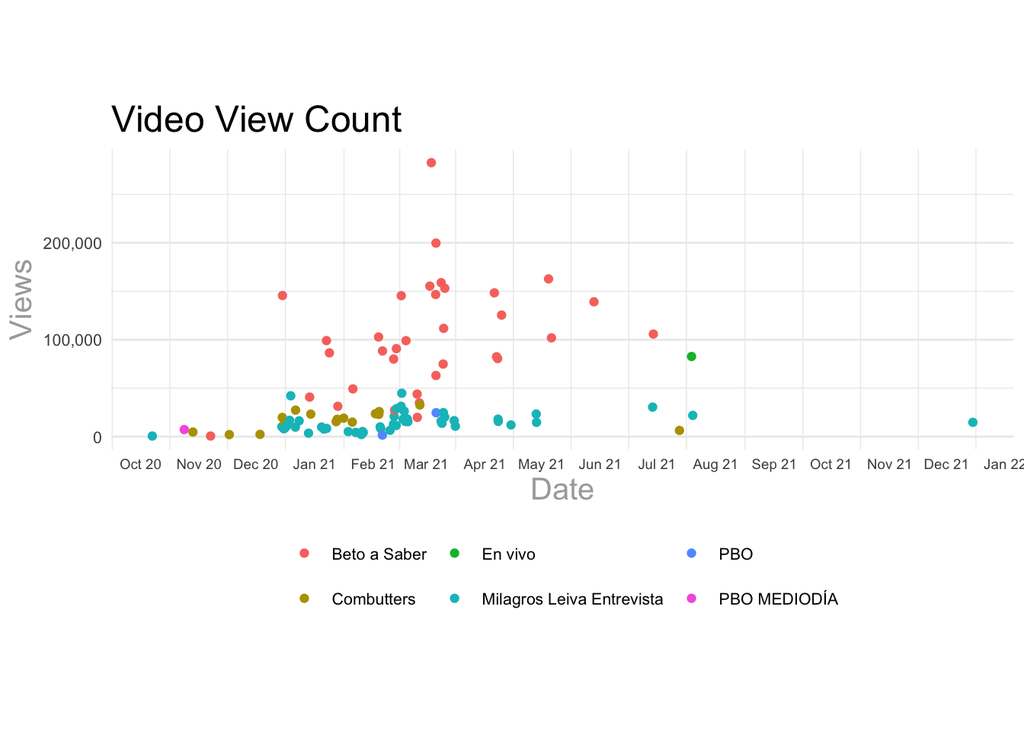

### Plotting number of comments by date and program

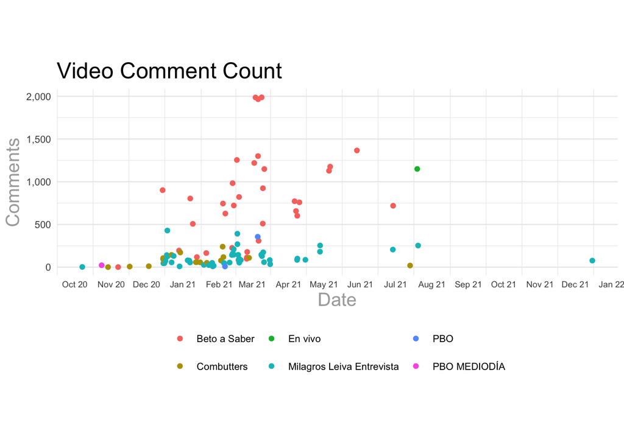

### Plotting number of likes by date and program

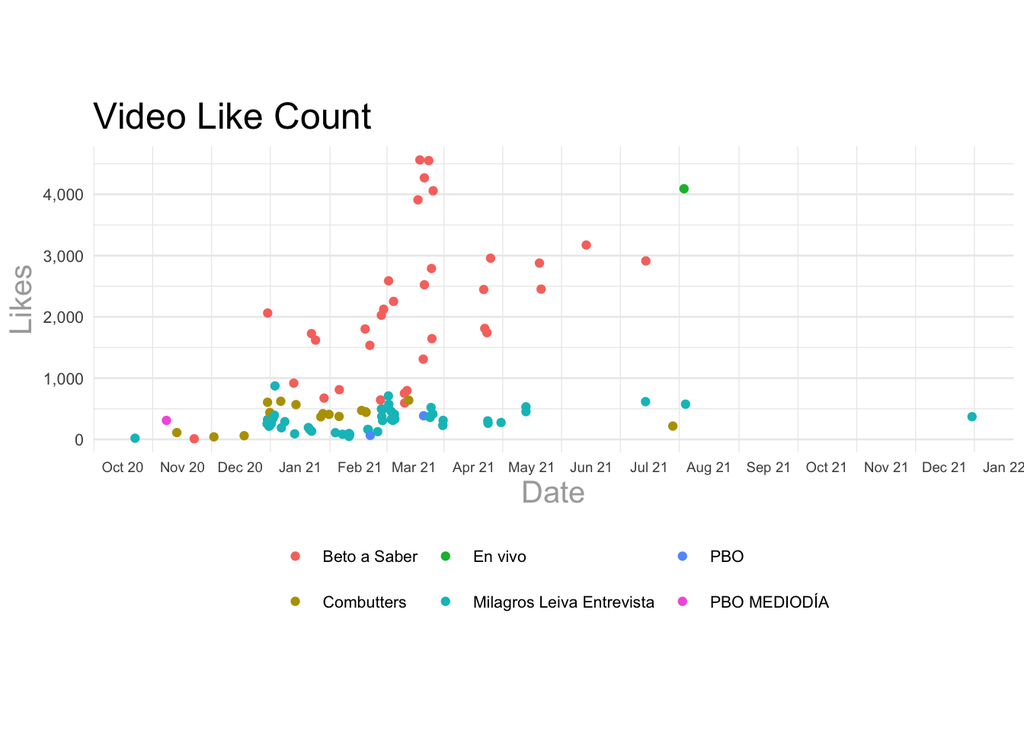

### *Case Study*

```r
# Loads file to create dataframe for hand coding and selects desired column
file <- rio::import("data/willax_pbo_youtube_vids/wil_pbo_sinoph_comments.json")
View(file)

View(file[[1]]) # Check that video is the desired one
colnames(file[[1]]) # Check column names for

video_comments <- (file[[1]]) |>
  mutate(comment_publish_date = as_datetime(comment_publish_date, origin = "1970-01-01")) |>
  mutate(comment_like_count = ifelse(!is.na(as.numeric(comment_like_count)), as.numeric(comment_like_count), 0)) |>
  mutate(reply_count = as.numeric(reply_count)) |>
  mutate(attitude = NA_character_) |>
  mutate(comment_date = as_date(comment_publish_date),
         comment_time = format(comment_publish_date, "%H:%M:%S")) |>
  select(video_id,
         comment_date,
         comment_time,
         comment_id,
         comment = text,
         attitude,
         comment_likes = comment_like_count,
         replies = reply_count,
         commenter_channel_id,
         commenter_channel_display_name,
         commenter_rating,
         comment_parent_id) |>
  arrange(comment_date)

# str(video_comments)
# head(video_comments)
summary(video_comments)

# Save dataframe into .csv
write.csv(video_comments, "data/FILENAME.csv", row.names = FALSE)

###  Loads file and translates numerica hand-code into qualitative values
## Creates summary for commenters and viewers in relation to data on columns "attitude" (hand code)
coded_file <- rio::import("data/willax_pbo_youtube_vids/df_sinoph_comment_dis_code1JC.csv")

video_comments_summary <- coded_file |>
  mutate(replies = as.numeric(replies)) |>
  mutate(attitude = as.numeric(attitude)) |>
  filter(!is.na(attitude)) |>
  mutate(attitude = case_when(
    attitude == 0 ~ "Neutral",
    attitude == 1 ~ "Favor (Politically)",
    attitude == 2 ~ "Favor (Sinopharm/Genocide)",
    attitude == 3 ~ "Against",
    TRUE ~ as.character(attitude)  # Safety catch to convert any other numbers to character
  )) |>
  group_by(attitude) |>
  summarize(
    total_commenters = n(),
    unique_commenters = n_distinct(commenter_channel_display_name, na.rm = TRUE),
    non_unique_commenters = total_commenters - unique_commenters,
    total_likes = sum(comment_likes, na.rm = TRUE),
    .groups = 'drop'
  ) |>
  arrange(attitude)

# Dataframe summarising the coded obsercations
attude_summ_df <-coded_file |>
  summarise(
    Coded_Observations = sum(!is.na(attitude)),
    Total_NAs = sum(is.na(attitude))
  )
# print(summary_df) #Check and debug

# Table for attitude summary
attude_summ_tab <- attude_summ_df |>
  gt() |>
  tab_header(
    title = "Attitude Totals"
  ) |>
  cols_label(
    Coded_Observations = "Coded Observations",
    Total_NAs = "NAs"
  )
attude_summ_tab

# Video Comments Table --------
comm_table <- video_comments_summary |>
  gt() |>
  tab_header(
    title = "Comments Summary"
  ) |>
  cols_label(
    attitude = "Attitude Toward Video",
    total_commenters = "Total Commenters",
    unique_commenters = "Unique Commenters",
    non_unique_commenters = "Recurrent Commenters",
    total_likes = "Total Likes",
  ) |>
  data_color(
    columns = c(unique_commenters, non_unique_commenters),
    direction = "row",
    method = "auto")
comm_table

# Unique and Recurrent Commenters ------
# Calculate non-unique commenters and their posting frequency
commenter_frequencies <- coded_file |>
  count(commenter_channel_display_name, sort = TRUE, name = "posts_count") |>
  filter(commenter_channel_display_name != "NA") |>
  count(posts_count, name = "commenter_count")

comm_freq_tbl <- commenter_frequencies |>
  gt() |>
  tab_header(
    title = "Commenter Frequency"
  ) |>
  cols_label(
    commenter_count = "Commenters",
    posts_count = "Posts"
  ) |>
  data_color(columns = posts_count,
             direction = "column",
             target_columns = NULL,
             method = "auto",
             bins = 8,
             quantiles = 4,
             ordered = FALSE,
             reverse = TRUE)|>
  cols_move_to_start(
    columns = c(commenter_count)
  )
comm_freq_tbl
```

[output not shown]